# TeoNAM STAM — GWAS Manhattan with candidate genes (Chen 2019 Fig 4C) [118K panel]

Empirical-truth validation on the authentic 118,838-SNP Chen 2019 GWAS panel

Author

Fausto Rodríguez-Zapata

Published

July 8, 2026

**What this is.** The STAM GWAS Manhattan (Chen 2019 Fig 4C) reproduced on the TeoNAM genotypes, with the domestication candidate genes placed at their **real B73 v5 coordinates** (MaizeGDB `genemodel_locus` → `b73_gene_coords`), a red star at each gene’s genomic position, and the LOD = 5 dotted significance line.

**Important118K-panel edition**

This is the `-118k` edition: every **figure and table** is regenerated on the **authentic 118,838-SNP Chen 2019 GWAS panel** (Qiuyue Chen’s Drive release, lifted AGPv2→v5), not the earlier 51K map-panel approximation. Data paths point to the `*_118k*` artifacts (GWAS scan `stam_gwas_scan_118k.csv`; the four `stam_gwas_<caller>_118k_sweep.csv`; 118K het-fraction tables). The **JLM QTL-recovery arm** (Fig 4A lollipop, candidate-overlap) deliberately keeps its own inputs — JLM runs on the 6K JLM panel, a *separate* reproduction unaffected by the GWAS marker set.

**Truth for the coverage sweeps** is the 118K panel block-smoothed with FSFHap (Chen’s params; parental ancestry mosaic, ~9 breakpoints/chr) — see DATA.md (`teonam_gwas118k_v5_dosage_fsfhap`).

This notebook **loads pre-computed CSVs and plots** (compute lives in the `scripts/` directory): the per-marker GWAS scans (`teonam_stam_gwas_scan.R` interpolated / `teonam_stam_gwas_family_imputed.R` family-imputed) and the candidate-gene overlap (`teonam_candidate_overlap.R`). We show both the **family-imputed** scan (natural scatter) and the **interpolated/densified** scan (block-terraced — the artifact of step-interpolated genotypes, see below).

```r
library(here)
library(data.table)
library(ggplot2)
library(fastman)
library(ggrepel)
library(ggtext)
library(scales)
library(cowplot)
```

```r
# Coordinate transformer replicating fastman_gg's internal x layout, so we can
# place gene labels / lines at arbitrary (chr, bp). From inv4m make_manhattan_plots.Rmd.
get_transformer <- function(m) {
  cmat <- do.call(rbind, lapply(
    split(m[order(m$CHR, m$BP), ], m$CHR[order(m$CHR, m$BP)]),
    function(d) {
      data.frame(
        CHR = d$CHR[1], min_bp = min(d$BP),
        width = max(d$BP) - min(d$BP),
        medgap = if (nrow(d) > 1) median(diff(sort(d$BP))) else 1
      )
    }
  ))
  cmat <- cmat[order(cmat$CHR), ]
  maxgap <- max(cmat$medgap, na.rm = TRUE)
  numc <- nrow(cmat)
  cmat$base <- 0
  cmat$midp <- 0
  cmat$midp[1] <- cmat$width[1] / 2
  for (i in 2:numc) {
    cmat$base[i] <- cmat$base[i - 1] + cmat$width[i - 1] + maxgap
    cmat$midp[i] <- cmat$base[i] + cmat$width[i] / 2
  }
  fac <- numc / cmat$midp[numc]
  cmat$basef <- fac * cmat$base
  function(chr, bp) {
    i <- match(chr, cmat$CHR)
    fac * (bp - cmat$min_bp[i]) + cmat$basef[i]
  }
}

LOD <- 5 # Chen 2019: P < 1e-5 (LOD = 5)

#' STAM GWAS Manhattan with candidate genes at their true v5 positions.
#' Odd chromosomes black, even gray75; y-axis expanded one major-tick unit above
#' the top tick; gene labels repelled into the headroom above the maximum peak
#' (segments back to the red star at each gene's local peak).
#' @param scan_csv per-marker scan (SNP, CHR, BP[v5], P)
#' @param title    plot title
#' @param out_png  optional path to save a PNG
plot_stam_manhattan <- function(scan_csv, title, out_png = NULL, mark = NULL) {
  scan <- if (is.data.frame(scan_csv)) as.data.frame(scan_csv) else as.data.frame(fread(scan_csv))
  scan <- scan[is.finite(scan$P) & scan$P > 0, ]
  m <- scan[order(scan$CHR, scan$BP), c("SNP", "CHR", "BP", "P")]

  ov <- fread(here("results/sim/teonam/stam_candidate_overlap.csv")) # symbol, chr, start (v5)
  # star height = local max -log10P within +/-500 kb IN THIS scan
  ov[, y := vapply(seq_len(.N), function(i) {
    w <- m$P[m$CHR == chr[i] & abs(m$BP - start[i]) <= 5e5]
    if (length(w)) -log10(min(w)) else NA_real_
  }, numeric(1))]
  tr <- get_transformer(m)
  ov[, BPn := tr(chr, start)]
  ov <- ov[is.finite(y)]

  mp <- -log10(min(m$P)) # maximum peak
  ticks <- pretty(c(0, mp))
  unit <- diff(ticks)[1]
  ytop <- max(ticks) + unit # one major-tick unit of headroom

  p <- fastman_gg(
    m = m, snp = "SNP", col = c("black", "gray75"), maxP = mp,
    genomewideline = NULL, suggestiveline = NULL,
    ylab = expression(-log[10](italic(P))), xlab = ""
  ) +
    geom_hline(yintercept = LOD, linetype = "dotted", linewidth = 0.7, color = "black") +
    geom_point(
      data = ov, aes(x = BPn, y = y), inherit.aes = FALSE,
      shape = 8, size = 3, stroke = 1, color = "red"
    ) +
    ggrepel::geom_text_repel(
      data = ov, aes(x = BPn, y = y, label = symbol),
      inherit.aes = FALSE, fontface = "italic", size = 5,
      segment.color = "grey50", min.segment.length = 0, box.padding = 0.5,
      max.overlaps = Inf, ylim = c(mp + 0.3 * unit, ytop)
    ) + # above the max peak
    ggtitle(title) +
    theme_classic(base_size = 18) +
    scale_y_continuous(
      breaks = ticks, limits = c(0, ytop),
      expand = expansion(mult = c(0.01, 0))
    ) +
    theme(
      plot.title = element_markdown(hjust = 1, size = 16, face = "bold"),
      legend.position = "none",
      panel.grid.major.y = element_line(color = "grey90", linewidth = 0.2)
    )

  if (!is.null(mark)) { # optional dashed marker at an arbitrary locus
    xm <- tr(mark$chr, mark$bp)
    p <- p + geom_vline(xintercept = xm, linetype = "dashed", color = "red", linewidth = 0.5)
  }
  if (!is.null(out_png)) ggsave(out_png, p, width = 9, height = 4.6, dpi = 200, bg = "white")
  p
}

#' Chen 2019 Fig 4A: JLM QTL genomic distribution as a lollipop plot.
#' Full 10-chromosome axis is obtained by passing the dense scan to fastman_gg
#' with fully transparent points (col = transparent); the JLM QTL are overlaid as
#' blue stems + points, candidate genes labeled bold-italic above.
#' @param jlm_txt  TASSEL StepwiseOLSModelFitter output (stam_jlm_native1.txt): Name,
#'   Locus, Position (v5 bp), `pr>F`
#' @param scan_csv dense per-marker scan, only used (transparent) to lay out the axis
plot_stam_lollipop <- function(jlm_txt, scan_csv, title, out_png = NULL) {
  scan <- as.data.frame(fread(scan_csv))
  scan <- scan[is.finite(scan$P) & scan$P > 0, ]
  maxis <- scan[order(scan$CHR, scan$BP), c("SNP", "CHR", "BP", "P")]

  j <- fread(jlm_txt)
  j <- j[!(Name %in% c("mean", "Family", "Error"))]
  q <- data.table(
    SNP = j$Name, CHR = as.integer(j$Locus), BP = as.integer(j$Position),
    logP = -log10(as.numeric(j$`pr>F`))
  )
  q <- q[logP >= LOD] # keep only QTL significant at LOD 5 (-log10P >= 5)
  ov <- fread(here("results/sim/teonam/stam_candidate_overlap.csv")) # symbol, chr, start (v5)
  ov <- ov[symbol %in% c("ts2", "tb1", "tru1", "zmm16", "tsh4")] # JLM Fig-4A candidates (an1 is GWAS-only)
  q[, gene := ""] # assign each candidate gene to its NEAREST JLM QTL (1:1)
  for (i in seq_len(nrow(ov))) {
    idx <- which(q$CHR == ov$chr[i])
    if (length(idx)) {
      k <- idx[which.min(abs(q$BP[idx] - ov$start[i]))]
      q$gene[k] <- ov$symbol[i]
    }
  }
  tr <- get_transformer(maxis)
  q[, BPn := tr(CHR, BP)]

  maxlogP <- max(q$logP)
  brks <- seq(0, floor(maxlogP / 10) * 10, by = 10)
  ytop <- maxlogP * 1.18 # headroom for the top label

  p <- fastman_gg(
    m = maxis, snp = "SNP", col = c("#00000000", "#00000000"),
    maxP = maxlogP, genomewideline = NULL, suggestiveline = NULL,
    ylab = expression(-log[10](italic(P))), xlab = ""
  ) +
    geom_segment(
      data = q, aes(x = BPn, xend = BPn, y = 0, yend = logP),
      inherit.aes = FALSE, color = "blue", linewidth = 0.5
    ) +
    geom_point(
      data = q, aes(x = BPn, y = logP), inherit.aes = FALSE,
      color = "blue", size = 2.5
    ) +
    ggrepel::geom_text_repel(
      data = q[gene != ""], aes(x = BPn, y = logP, label = gene),
      inherit.aes = FALSE, fontface = "bold.italic", size = 5,
      segment.color = NA, box.padding = 0.4, point.padding = 0.3,
      nudge_y = 0.05 * maxlogP, seed = 1, max.overlaps = Inf
    ) +
    ggtitle(title) + theme_classic(base_size = 18) +
    scale_y_continuous(breaks = brks, limits = c(0, ytop), expand = expansion(mult = c(0.01, 0))) +
    theme(
      plot.title = element_markdown(hjust = 1, size = 16, face = "bold"),
      legend.position = "none",
      panel.grid.major.y = element_line(color = "grey90", linewidth = 0.2)
    )
  if (!is.null(out_png)) ggsave(out_png, p, width = 9, height = 4, dpi = 200, bg = "white")
  p
}

#' Coverage-sweep line-Manhattan (geom_line, one line per coverage).
#' −log10P vs genomic position along the union grid; `group = interaction(CHR,
#' coverage)` so lines never connect across chromosomes. Color = coverage on a
#' viridis ramp, the λ = ∞ truth baseline in black. LOD = 5 dotted. NO gene labels.
#' Reused for the control / nNIL / RTIGER panels of the degradation composite.
#' @param sweep_csv combined sweep CSV (SNP, CHR, BP[v5], P, coverage; coverage=Inf
#'   for the λ=∞ baseline rows)
#' @param title panel title (markdown)
#' @param legend show the coverage legend (FALSE for composite panels sharing one)
#' @param base_size theme base size
plot_sweep_line <- function(sweep_csv, title, legend = TRUE, base_size = 14) {
  sw <- as.data.table(fread(sweep_csv))
  sw <- sw[is.finite(P) & P > 0]
  sw[, logP := -log10(P)]
  # x layout from the union grid (every coverage carries the identical marker set)
  tr <- get_transformer(as.data.frame(sw[coverage == sw$coverage[1], .(CHR, BP)]))
  sw[, BPn := tr(CHR, BP)]

  # Legend order: infinity (truth) at top, then coverage in descending order.
  cov_levels <- c("∞", "20", "10", "5", "1", "0.5", "0.2", "0.1")
  sw[, cov_lab := factor(ifelse(is.finite(coverage), formatC(coverage), "∞"),
    levels = cov_levels
  )]
  # Colour mapping is fixed by coverage value (0.1 = darkest viridis ... 20 =
  # lightest; ∞ = black), independent of the legend order above.
  cov_asc <- c("0.1", "0.2", "0.5", "1", "5", "10", "20")
  pal <- setNames(grDevices::hcl.colors(7, "viridis"), cov_asc)
  pal["∞"] <- "black"
  axis_df <- sw[, .(mid = (min(BPn) + max(BPn)) / 2), by = CHR][order(CHR)]
  ytop <- 20 # shared y-limit across all panels for cross-method comparison

  # Draw order (z-stack): 20x first, then descending to 0.1x, and ∞ LAST so the
  # darker low-coverage / black-truth profiles sit on top. dord = -coverage sorts
  # finite coverage descending (20 -> -20 first); ∞ -> Inf sorts last.
  sw[, dord := ifelse(is.finite(coverage), -coverage, Inf)]

  ggplot(
    sw[order(dord, CHR, BP)],
    aes(x = BPn, y = logP, color = cov_lab, group = interaction(CHR, coverage))
  ) +
    geom_line(linewidth = 0.4) +
    geom_hline(yintercept = LOD, linetype = "dotted", linewidth = 0.7, color = "grey30") +
    scale_color_manual(values = pal, name = "coverage (×)", drop = FALSE) +
    scale_x_continuous(breaks = axis_df$mid, labels = axis_df$CHR, expand = c(0.01, 0)) +
    scale_y_continuous(limits = c(0, ytop), expand = expansion(mult = c(0.01, 0))) +
    labs(x = "chromosome", y = expression(-log[10](italic(P))), title = title) +
    theme_classic(base_size = base_size) +
    theme(
      plot.title = element_markdown(hjust = 0, size = base_size, face = "bold"),
      panel.grid.major.y = element_line(color = "grey90", linewidth = 0.2),
      # legend INSIDE the plotting area, top-right corner (top panel only)
      legend.position = if (legend) c(0.995, 0.97) else "none",
      legend.justification = c(1, 1),
      legend.background = element_rect(fill = scales::alpha("white", 0.7), colour = NA),
      legend.key.size = unit(0.85, "lines"),
      legend.title = element_text(size = base_size - 3),
      legend.text = element_text(size = base_size - 4),
      legend.margin = margin(1, 3, 1, 3)
    ) +
    guides(color = guide_legend(override.aes = list(linewidth = 1.2)))
}
```

## Candidate genes: closest marker vs most-significant marker (v5)

```r
sc <- fread(here("data/teonam/stam_gwas_scan_118k.csv"))
sc <- sc[is.finite(P) & P > 0][, logP := -log10(P)]
cand <- c(
  ts2 = "STAM1.1", tb1 = "STAM1.2", tru1 = "STAM3.1",
  zmm16 = "STAM3.2", tsh4 = "STAM7.1", an1 = "GWAS(chr1)"
)
sym <- fread(here("data/ref/maize_v5_gene_symbols.tsv"))
setnames(sym, c("gene_id", "symbol"))
coord <- fread(here("data/ref/b73_gene_coords.tsv"),
  header = FALSE,
  col.names = c("gene_id", "chr", "start", "end")
)
gg <- merge(sym[symbol %in% names(cand)], coord, by = "gene_id")
gg[, chr := as.integer(sub("^chr", "", chr))][, qtl := cand[symbol]]
WIN <- 5e5 # +/-500 kb around the gene body (1 Mb window)
ctab <- rbindlist(lapply(seq_len(nrow(gg)), function(i) {
  ch <- gg$chr[i]
  s <- gg$start[i]
  e <- gg$end[i]
  m <- sc[CHR == ch]
  d <- pmax(0L, pmax(s - m$BP, m$BP - e))
  kc <- which.min(d) # closest to gene body
  w <- m[BP >= s - WIN & BP <= e + WIN]
  kw <- which.max(w$logP) # max signal in window
  data.table(
    gene = gg$symbol[i], QTL = gg$qtl[i], chr = ch, `gene start (v5)` = s,
    `closest Δstart (bp)` = m$BP[kc] - s, `closest -log10P` = round(m$logP[kc], 2),
    `window-max Δstart (bp)` = w$BP[kw] - s, `window-max -log10P` = round(w$logP[kw], 2)
  )
}))
setorder(ctab, chr, `gene start (v5)`)
knitr::kable(ctab, format.args = list(big.mark = ","), caption = paste(
  "STAM candidate genes (B73 v5): the CLOSEST marker vs the highest -log10P marker",
  "within +/-500 kb (authentic 118K GWAS scan, 118,514 markers). Δstart = marker bp -",
  "gene start (v5), signed (negative = upstream); the two markers differ at every gene."
))
```

STAM candidate genes (B73 v5): the CLOSEST marker vs the highest -log10P marker within +/-500 kb (authentic 118K GWAS scan, 118,514 markers). Δstart = marker bp - gene start (v5), signed (negative = upstream); the two markers differ at every gene.

| gene | QTL | chr | gene start (v5) | closest Δstart (bp) | closest -log10P | window-max Δstart (bp) | window-max -log10P |
| --- | --- | --- | --- | --- | --- | --- | --- |
| ts2 | STAM1.1 | 1 | 46,511,946 | 1,592 | 3.30 | 59,560 | 11.62 |
| an1 | GWAS(chr1) | 1 | 246,895,757 | 656 | 7.29 | -368,239 | 12.14 |
| tb1 | STAM1.2 | 1 | 272,330,564 | -92,455 | 4.76 | -263,817 | 19.84 |
| tru1 | STAM3.1 | 3 | 152,086,191 | 420 | 6.77 | 149,536 | 14.18 |
| zmm16 | STAM3.2 | 3 | 176,074,772 | 1,564 | 13.64 | -401,160 | 15.44 |
| tsh4 | STAM7.1 | 7 | 138,540,580 | 372 | 5.74 | -117,306 | 7.94 |

## JLM QTL genomic distribution (Fig 4A)

The STAM QTL detected by JLM as a lollipop plot across all 10 chromosomes (height = −log10 P from TASSEL’s stepwise model), candidate genes bold-italic above the corresponding QTL. Reproduces Chen 2019 Fig 4A.

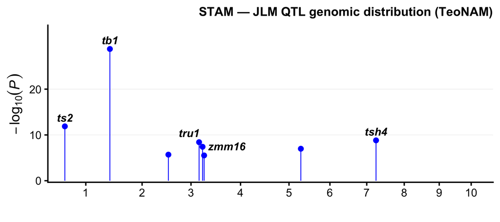

```r
p_lolli <- plot_stam_lollipop(
  here("data/teonam/tassel/stam_jlm_native1.txt"),
  here("data/teonam/stam_gwas_scan_118k.csv"),
  "STAM — JLM QTL genomic distribution (TeoNAM)",
  here("results/sim/teonam/stam_jlm_lollipop_118k.png")
)
p_lolli
```

## Authentic 118K panel — OLS scan (Fig 4C)

Chen 2019’s imputed 118,838-SNP GWAS panel, scanned here with **OLS** (`STAM ~ Family + marker`, 1-df F) — *not* Chen’s Fig-4C model. Chen used a **mixed model (Q = 5 PCs + K = kinship)**; without that structure/kinship correction this OLS scan runs inflated (hotter, broader peaks), so it does **not** reproduce Fig 4C. Chen’s Fig-4C model — the same 118K panel run through the MLM (Q+K) — is in `teonam-stam-mlm-gwas-118k`.

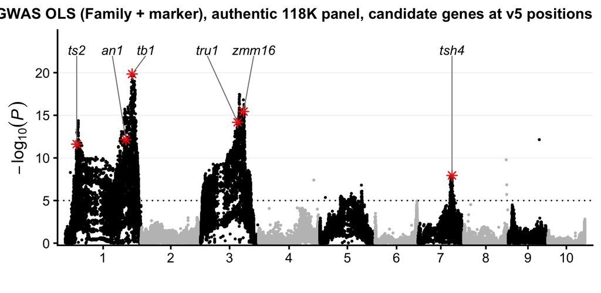

```r
p_unimp <- plot_stam_manhattan(
  here("data/teonam/stam_gwas_scan_118k.csv"),
  "STAM — GWAS OLS (Family + marker), authentic 118K panel, candidate genes at v5 positions",
  here("results/sim/teonam/stam_gwas_manhattan_annotated_118k.png")
)
p_unimp
```

## Ancestry-imputed panel (FSFHap block-smoothed) — OLS scan

The same OLS model (`STAM ~ Family + marker`), but on the **ancestry-imputed** 118K truth: the panel block-smoothed with TASSEL5 **FSFHap** (Chen’s params; parental A/C output, ~9 breakpoints/chr) into a clean W22↔︎teosinte mosaic, then scanned. Because ancestry is piecewise-constant, contiguous markers share a call → identical p-values → **block-terraced** profile (peaks still correctly located). Contrast with the per-SNP raw panel above: same peaks, but the scatter collapses to ancestry blocks. This is the n=∞ complete-truth reference the coverage sweeps degrade from.

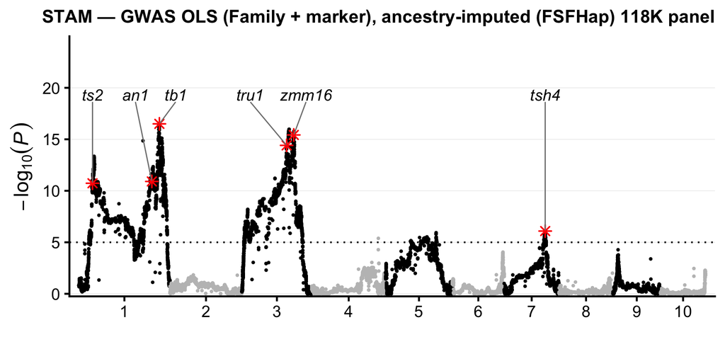

```r
p_interp <- plot_stam_manhattan(
  here("data/teonam/stam_gwas_scan_118k_complete_baseline.csv"),
  "STAM — GWAS OLS (Family + marker), ancestry-imputed (FSFHap) 118K panel",
  here("results/sim/teonam/stam_gwas_manhattan_118k_fsfhap.png")
)
p_interp
```

## Composite (A: JLM lollipop · B: OLS raw 118K · C: OLS ancestry-imputed 118K)

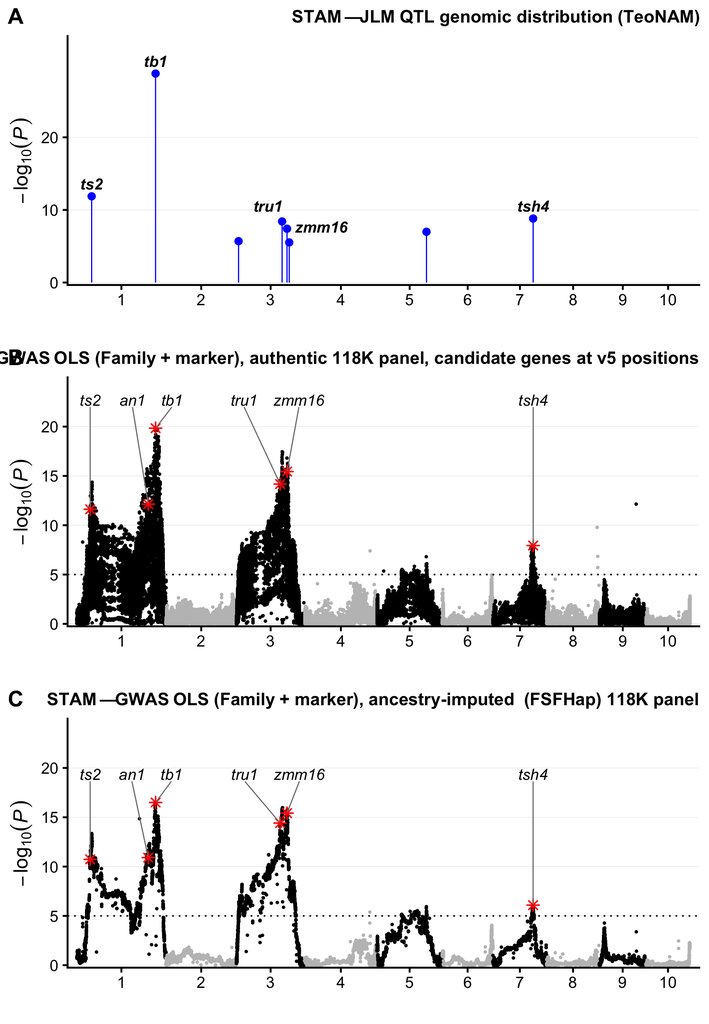

```r
composite <- cowplot::plot_grid(
  p_lolli, p_unimp, p_interp,
  ncol = 1, labels = c("A", "B", "C"), label_size = 20, align = "v", axis = "lr"
)
ggsave(here("results/sim/teonam/stam_composite_118k.png"), composite,
  width = 9, height = 13, dpi = 200, bg = "white"
)
composite
```

## RTIGER ancestry vs sequencing coverage (degradation sweep)

How low-coverage sequencing degrades the STAM signal **through the RTIGER ancestry caller**: for each family × coverage `λ ∈ {0.1, 0.2, 0.5, 1, 5, 10, 20, ∞}×` we Poisson-sample reads from the **authentic 118K per-SNP genotypes** (`.draw_counts`, `pi_floor=0, k_decay=1, error=0.01`), infer ancestry with `call_ancestry(caller = "rtiger", rigidity = 2)` (calibrated `rigidity_star`) on the **0.1 cM inference grid**, back-project the segments onto the full 118,514-marker union, and run the `STAM ~ Family + marker` scan. λ = ∞ is RTIGER at perfect coverage (its own ceiling). Compute: `scripts/teonam_rtiger_sweep_118k.R --generate`; this chunk loads and plots.

Line-Manhattan (`geom_line`, one line per coverage; chromosomes never connect via `group = interaction(CHR, coverage)`): coverage on a viridis ramp, λ = ∞ in **black**, LOD = 5 dotted. RTIGER holds the *tb1* / chr3 signal well down to low coverage, but on the real per-SNP truth the peak height is **not** monotone in coverage — RTIGER’s fixed rigidity smooths differently as read depth changes, so moderate coverage can look cleaner than perfect coverage. Read *where signal survives*, not exact peak heights; one replicate per cell.

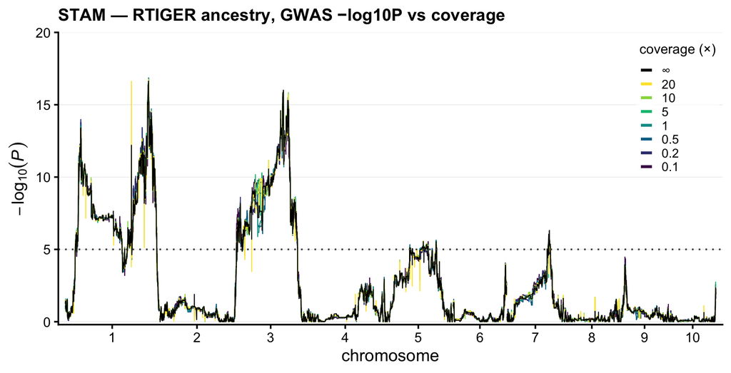

```r
p_sweep <- plot_sweep_line(
  here("results/sim/teonam/stam_gwas_rtiger_118k_sweep.csv"),
  "STAM — RTIGER ancestry, GWAS −log10P vs coverage",
  base_size = 15
)
ggsave(here("results/sim/teonam/stam_gwas_rtiger_118k_sweep_manhattan.png"),
  p_sweep,
  width = 9, height = 4.6, dpi = 200, bg = "white"
)
p_sweep
```